# sample

시작전

```r
library(ggplot2)
library(googleVis)
library(plyr)
library(dplyr)
```

1. mpg 데이터의 cty(도시 연비)와 hwy(고속도로 연비) 간에 어떤 관계가 있는지 알아보려고 합니다. x축은 cty, y축은 hwy로 된 산점도를 만들어 보세요

```r
mpg
```

```
## # A tibble: 234 x 11
##    manufacturer model displ  year   cyl trans drv     cty   hwy fl    class
##    <chr>        <chr> <dbl> <int> <int> <chr> <chr> <int> <int> <chr> <chr>
##  1 audi         a4      1.8  1999     4 auto~ f        18    29 p     comp~
##  2 audi         a4      1.8  1999     4 manu~ f        21    29 p     comp~
##  3 audi         a4      2    2008     4 manu~ f        20    31 p     comp~
##  4 audi         a4      2    2008     4 auto~ f        21    30 p     comp~
##  5 audi         a4      2.8  1999     6 auto~ f        16    26 p     comp~
##  6 audi         a4      2.8  1999     6 manu~ f        18    26 p     comp~
##  7 audi         a4      3.1  2008     6 auto~ f        18    27 p     comp~
##  8 audi         a4 q~   1.8  1999     4 manu~ 4        18    26 p     comp~
##  9 audi         a4 q~   1.8  1999     4 auto~ 4        16    25 p     comp~
## 10 audi         a4 q~   2    2008     4 manu~ 4        20    28 p     comp~
## # ... with 224 more rows
```

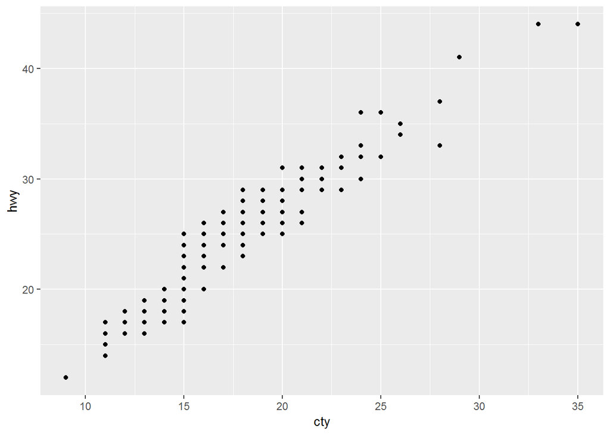

```r
data <- mpg

ggplot(data, aes(x = cty, y = hwy)) +
  geom_point()
```

```r
asia <- midwest
asia1_1 <- asia %>%
  select(poptotal,popasian)

asia1_2 <- filter(asia1_1, poptotal<500000 & popasian<=10000)
```

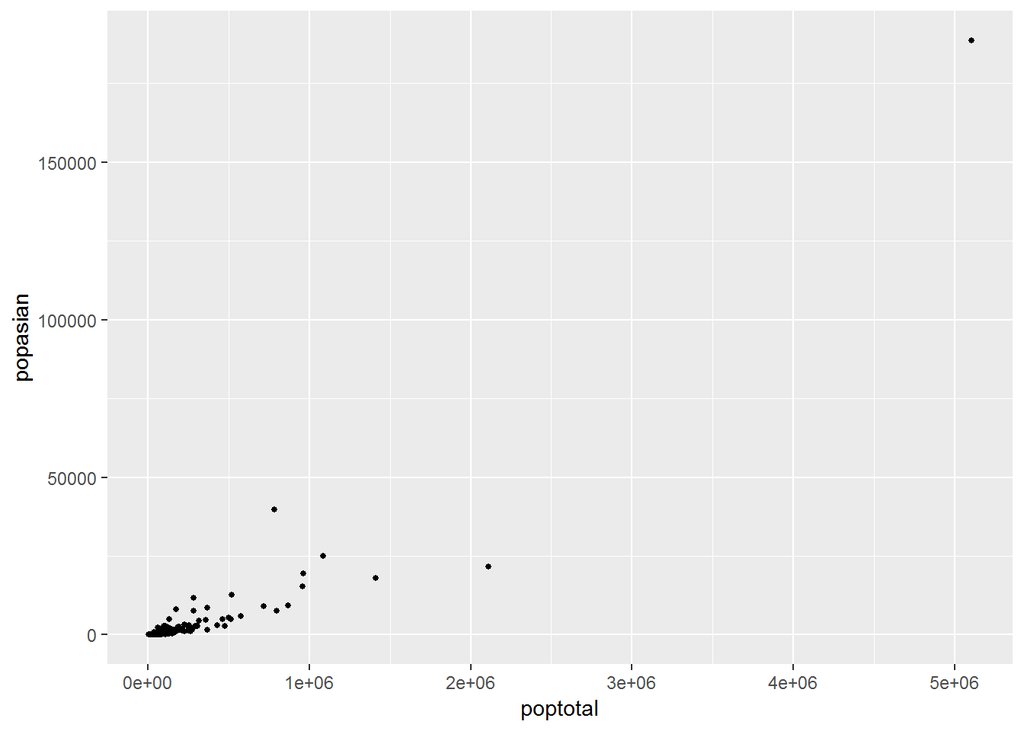

```r
asia1_2 <- filter(asia1_1, poptotal<500000 & popasian<=10000)

ggplot(asia, aes(x = poptotal, y= popasian )) +
  geom_point(size = 1)
```

3. 어떤 회사에서 생산한 “suv” 차종의 도시 연비가 높은지 알아보려고 합니다. “suv” 차종을 대상으로 평균 cty(도시 연비)가 가장 높은 회사 다섯 곳을 막대 그래프로 표현해 보세요. 막대는 연비가 높은 순으로 정렬하세요.

```r
data1 <- select(data, cty, class, manufacturer) %>%
  filter(class == 'suv')

data1 %>%
  group_by(manufacturer) %>%
  summarise(averge = mean(cty,na.rm = TRUE)) %>%
  arrange(desc(averge))
```

```
## # A tibble: 10 x 2
##    manufacturer averge
##    <chr>         <dbl>
##  1 subaru         18.8
##  2 toyota         14.4
##  3 nissan         13.8
##  4 jeep           13.5
##  5 mercury        13.2
##  6 ford           12.9
##  7 chevrolet      12.7
##  8 dodge          11.9
##  9 land rover     11.5
## 10 lincoln        11.3
```

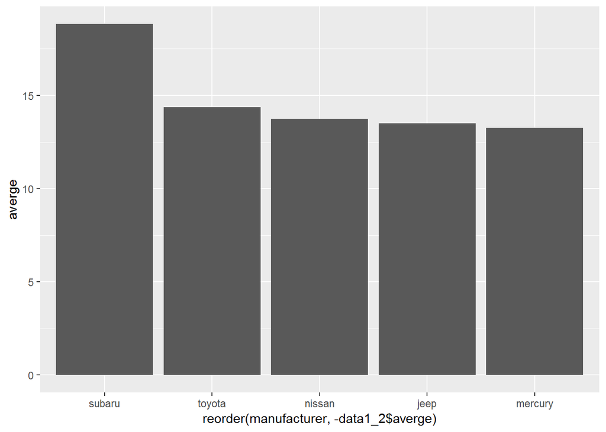

```r
data1_1 <- data1 %>%
  filter(manufacturer=='subaru' | manufacturer=='toyota' |
           manufacturer=='nissan' | manufacturer=='jeep' |
           manufacturer=='mercury')

data1_2 <- data1_1 %>%
  group_by(manufacturer) %>%
  summarise(averge = mean(cty,na.rm = TRUE))

ggplot(data1_2, aes(x = reorder(manufacturer, -data1_2$averge), y= averge)) +
         geom_bar(stat='identity')
```

4. 자동차 중에서 어떤 class(자동차 종류)가 가장 많은지 알아보려고 합니다. 자동차 종류별 빈도를 표현한 막대 그래프를 만들어 보세요.

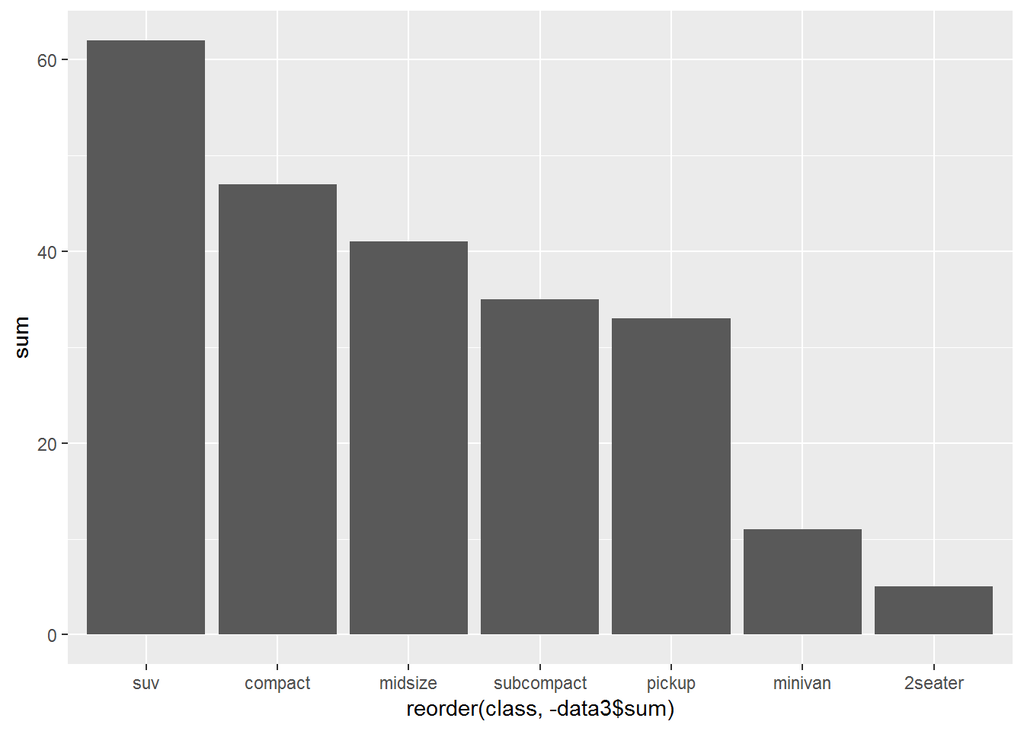

```r
data3 <- select(data, class) %>%
  mutate(T = 1) %>%
  group_by(class) %>%
  summarise(sum = sum(T))

ggplot(data3, aes(x=reorder(class, -data3$sum), y=sum)) +
  geom_bar(stat='identity')
```

5. economics 데이터를 이용해서 psavert(개인 저축률)가 시간에 따라서 어떻게 변해왔는지 알아보려고 합니다. 시간에 따른 개인 저축률의 변화를 나타낸 시계열 그래프를 만들어 보세요.

```r
economics
```

```
## # A tibble: 574 x 6
##    date         pce    pop psavert uempmed unemploy
##    <date>     <dbl>  <int>   <dbl>   <dbl>    <int>
##  1 1967-07-01  507. 198712    12.5     4.5     2944
##  2 1967-08-01  510. 198911    12.5     4.7     2945
##  3 1967-09-01  516. 199113    11.7     4.6     2958
##  4 1967-10-01  513. 199311    12.5     4.9     3143
##  5 1967-11-01  518. 199498    12.5     4.7     3066
##  6 1967-12-01  526. 199657    12.1     4.8     3018
##  7 1968-01-01  532. 199808    11.7     5.1     2878
##  8 1968-02-01  534. 199920    12.2     4.5     3001
##  9 1968-03-01  545. 200056    11.6     4.1     2877
## 10 1968-04-01  545. 200208    12.2     4.6     2709
## # ... with 564 more rows
```

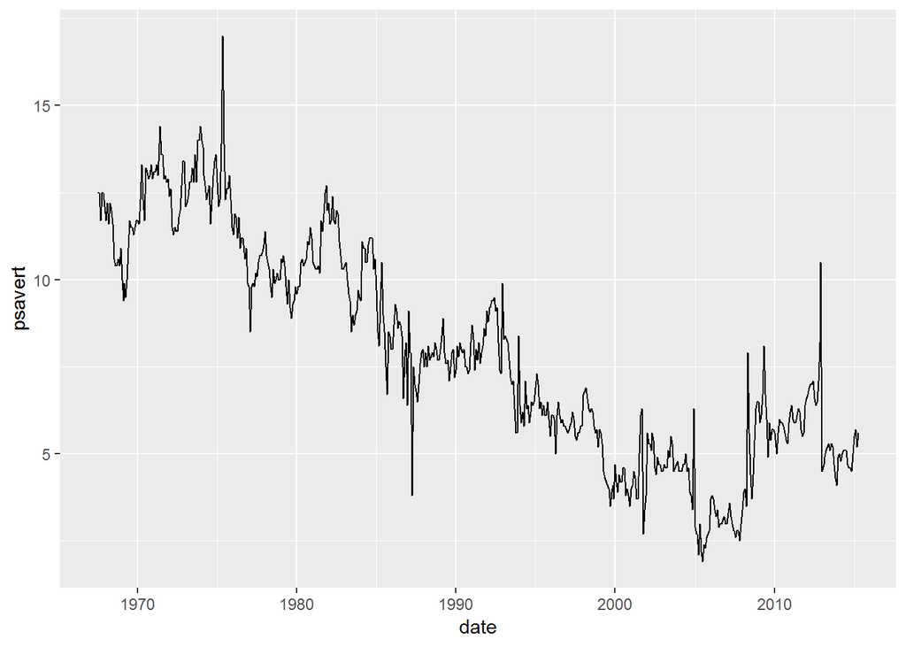

```r
data_e <- economics

data4 <-select(data_e, psavert, date)

ggplot(data_e, aes(x=date,y=psavert)) +
  geom_line()
```

6. class(자동차 종류)가 “compact”, “subcompact”, “suv”인 자동차의 cty(도시 연비)가 어떻게 다른지 비교해보려고 합니다. 세 차종의 cty를 나타낸 상자 그림을 만들어보세요.

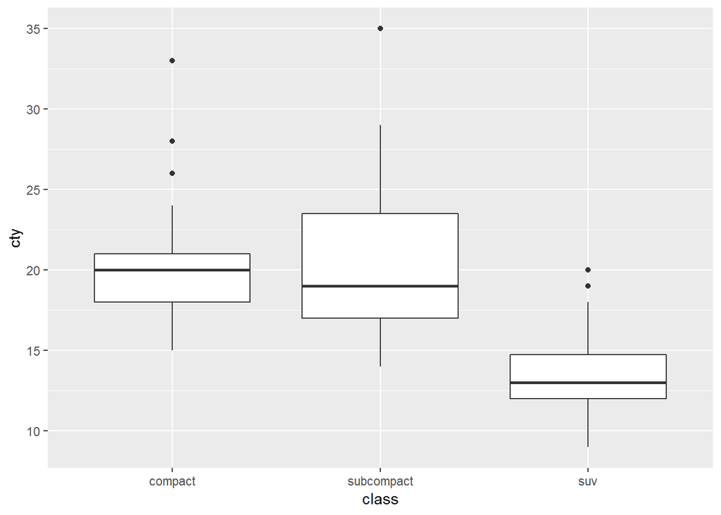

```r
data5 <- select(data, cty, class, manufacturer) %>%
  filter(class == 'suv' | class == 'compact' | class == 'subcompact')
#filter(class %in% c( 'suv','compact','subcompact')
ggplot(data5, aes(x=class, y=cty)) +
  geom_boxplot()
```

7. Diamonds 데이터 셋을 이용하여 다음 문제를 해결하세요. 단, 컬러, 제목, x축, y축 등 그래프를 예쁘게 작성하세요.
1. cut의 돗수를 보여주는 그래프를 작성하세요.

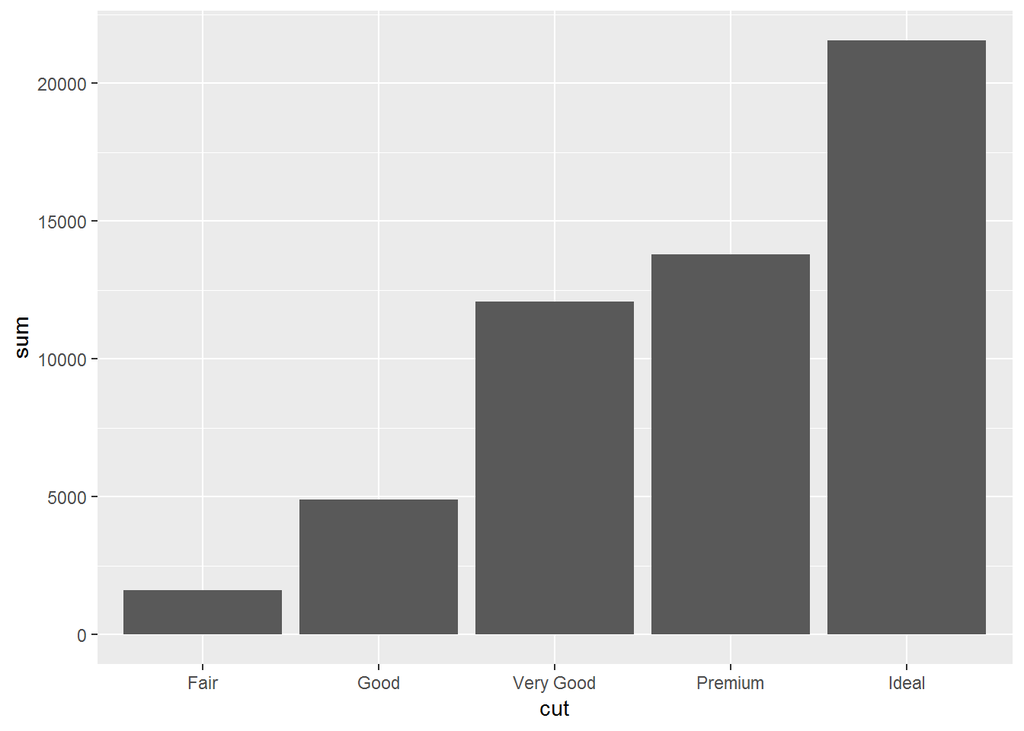

```r
data6 <- diamonds

data7 <- select(data6, cut) %>%
  mutate(nt = 1) %>%
  group_by(cut) %>%
  summarise(sum = sum(nt))

ggplot(data7, aes(x=cut, y=sum)) +
  geom_bar(stat='identity')
```

2. cut에 따른 가격의 변화를 보여주는 그래프를 작성하세요.

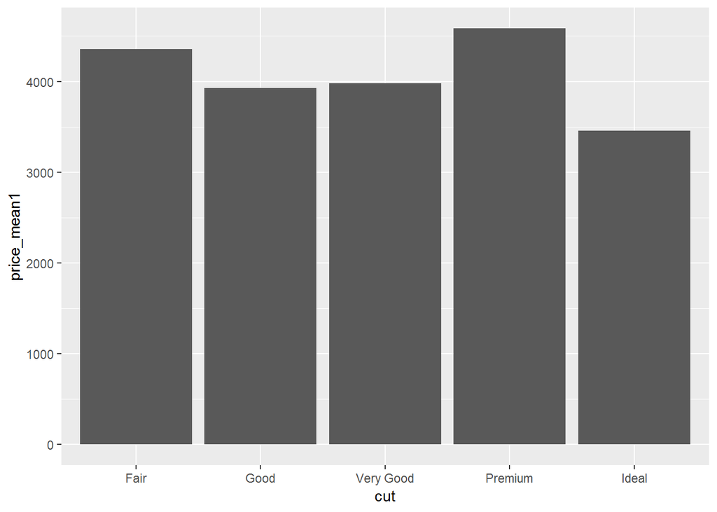

```r
data8 <- select(data6, cut, price) %>%
  group_by(cut) %>%
  summarise(price_mean1 = mean(price))

ggplot(data8, aes(x=cut,y=price_mean1,group=1)) +
  geom_bar(stat='identity')
```

3. cut과 color에 따른 가격의 변화를 보여주는 그래프를 작성하세요.

```r
data8 <- select(data6, cut, price) %>%
  group_by(cut) %>%
  summarise(price_mean1 = mean(price))

data9 <- select(data6, color, price) %>%
  group_by(color) %>%
  summarise(price_mean2 = mean(price))

gg1 <- ggplot(data8, aes(x=cut,y=price_mean1,group=1)) +
  geom_bar(stat='identity')

gg2 <- ggplot(data9, aes(x=color,y=price_mean2,group=1)) +
  geom_bar(stat='identity')
```